# TSRethinking2 Change points and structural breaks

Wayne Zhang

10/9/2021

```r
knitr::opts_chunk$set(fig.width = 8, fig.height = 4)
rm(list=ls())  # remove variables
library(changepoint) # changing point
library(strucchange) # structural change
library(tidyverse)
library(lubridate)
library(FinCal)
set.seed(123)
```

```r
dat <- tibble(
    ar1 = arima.sim(model = list(ar = 0.8), n = 200),
    ma1 = arima.sim(model = list(ma = 0.7), n = 200),
    arma10 = arima.sim(model = list(ar  = 0.4), n = 200),
    arma01 = arima.sim(model = list(ma = 0.5), n = 200),
    arma11 = arima.sim(model = list(ar = 0.4, ma = 0.5), n = 200),
    arma21 = arima.sim(model = list(ar = c(0.6,-0.2), ma = c(0.4)), n = 200)
)
```

Dominant feature of many time series is that today’s values are close to tomorrow’s values

# 1 Autoregressive Models

## 1.1 AR(1)

$$y_{t}=\phi y_{t-1}+\varepsilon_{t}$$
$$\varepsilon_{t}\sim \mathsf{i.i.d.} \mathcal{N}(0,\sigma^{2})$$

### 1.1.1 Moment

$$\begin{eqnarray}
\mathbb{E}\left[ y_{t}\right] &=&0 \\
\mathsf{var}[y_{t}] &=&\frac{\sigma^{2}}{1-\phi^2 } \\
\mathsf{cov}[y_{t},y_{t-j}] &=&\phi^{j} \mathsf{var}[y_{t}]
\end{eqnarray}$$

1. Mean
   $$\begin{equation}
   \mathbb{E}\left[ y_{t}\right] = \mathbb{E}\left[ \varepsilon_{t}+\phi \varepsilon_{t-1}+\phi^{2}\varepsilon_{t-2}+\phi^{3}\varepsilon_{t-3}+ \ldots \right] =0
   \end{equation}$$
2. Variance

$$\begin{eqnarray}
\gamma \left( 0\right) &=&\mathsf{var}\left[ y_{t}\right] =\mathbb{E}\big[ y_{t}-\mathbb{E}\left[ y_{t}\right] \big]^{2} \\
&=&\mathbb{E}\left[ \varepsilon_{t}+\phi \varepsilon_{t-1}+\phi^{2}\varepsilon_{t-2}+\phi^{3}\varepsilon_{t-3}+ \ldots \right]^{2} \\
&=&\mathsf{var}\left[ \varepsilon_{t}\right] +\phi ^{2}\mathsf{var}\left[ \varepsilon_{t-1}\right] +\phi^{4}\mathsf{var}\left[\varepsilon_{t-2}\right] +\phi^{6}\mathsf{var}\left[ \varepsilon_{t-3}\right] + \ldots \\
&=&\left( 1+\phi^{2}+\phi^{4}+\phi^{6}+ \ldots \; \right) \sigma^{2} \\
&=&\frac{1}{1-\phi^{2}}\sigma^{2}
\end{eqnarray}$$

3. Covariance

if $j = 1$

$$\begin{eqnarray}
\gamma \left( 1\right) &=&\mathbb{E}\Big[ \big(y_{t}-\mathbb{E}\left[ y_{t}\right] \big)\big(y_{t-1}-\mathbb{E}\left[ y_{t-1}\right] \big) \Big] \\
&=&\mathbb{E}\left[ (\varepsilon_{t}+\phi \varepsilon_{t-1}+\phi^{2}\varepsilon_{t-2}+ \ldots )\times (\varepsilon_{t-1}+\phi \varepsilon_{t-2}+ \ldots )\right] \\
&=&\left( \phi +\phi^{3}+\phi^{5}+ \ldots \right) \sigma^{2}=\phi \left( 1+\phi^{2}+\phi^{4}+ \ldots \right) \sigma^{2} \\
&=&\phi \frac{1}{1-\phi^{2}}\sigma^{2} \\
&=&\phi \mathsf{var}\left[ y_{t}\right]
\end{eqnarray}$$
if $j>1$
$$\begin{equation}
\gamma \left( j\right) =\mathbb{E}\Big[ \big(y_{t}-\mathbb{E}\left[ y_{t}\right] \big)\big( y_{t-j}-E \left[ y-j\right] \big) \Big] =\phi^{j} \mathsf{var} \left[ y_{t}\right]
\end{equation}$$

### 1.1.2 ACF

$$\begin{equation}
\rho \left( 0\right) =\frac{\gamma \left( 0\right) }{\gamma \left( 0\right) } =1,\ \rho \left( 1\right) =\frac{\gamma \left( 1\right) }{\gamma \left( 0\right) }=\phi , \ldots , \rho \left( j\right) =\frac{\gamma \left( j\right) }{\gamma \left( 0\right) }=\phi^{j}
\end{equation}$$

### 1.1.3 MA expression

$$\begin{eqnarray}
y_{t} &=&\phi y_{t-1}+\varepsilon_{t} \\
&=& \phi (\phi y_{t-2}+\varepsilon_{t-1})+\varepsilon_{t} \\
&=& \phi ^{2}(\phi y_{t-3}+\varepsilon_{t-2})+\phi \varepsilon_{t-1}+\varepsilon_{t} \\
&=& \vdots \\
&=& \phi^{j+1}y_{t-(j+1)}+\phi^{j}\varepsilon_{t-j} + \ldots + \phi^{2}\varepsilon_{t-2} + \phi \varepsilon_{t-1} + \varepsilon_{t}
\end{eqnarray}$$

Thus, AR(1) model can express as MA($\infty$) model. From here we know that $|phi|<1$ otherwise this TS will diverge.

### 1.1.4 Lag operators

: Lag operator: $L*y_t = y_{t -1}$

Thus, for AR(1) model we have:

$$\left( 1-\phi L\right) y_{t}=\varepsilon_{t}$$

if $|phi|<1$

we have

$$\begin{eqnarray}
\left( 1-\phi L\right)^{-1} \left( 1-\phi L\right) y_{t}&=&\left( 1-\phi L\right)^{-1}\varepsilon_{t} \\
y_{t}&=&\left( 1-\phi L\right)^{-1}\varepsilon_{t}
\end{eqnarray}$$

By geometric rule:

$$\begin{equation}
\left( 1-\phi L\right)^{-1}=\underset{j\rightarrow \infty }{\lim }\left( 1+\phi L+\left( \phi L\right)^{2}+ \ldots +\left( \phi L\right)^{j}\right)
\end{equation}$$

$$y_t = \left(\sum_{i = 0}^\infty(\phi L)^i\right) \varepsilon_t$$
### Impulse Response Function (IRF)

ACF equals the dynamic multipliers that may be summarised by the impulse response function

$$\begin{equation}
\frac{\partial y_{t}}{\partial \varepsilon_{t}}=1,\frac{\partial y_{t}}{\partial \varepsilon_{t-1}}=\phi , \ldots , \frac{\partial y_{t}}{\partial \varepsilon_{t-j}}=\phi^{j}
\end{equation}$$

### 1.1.5 Simulated AR

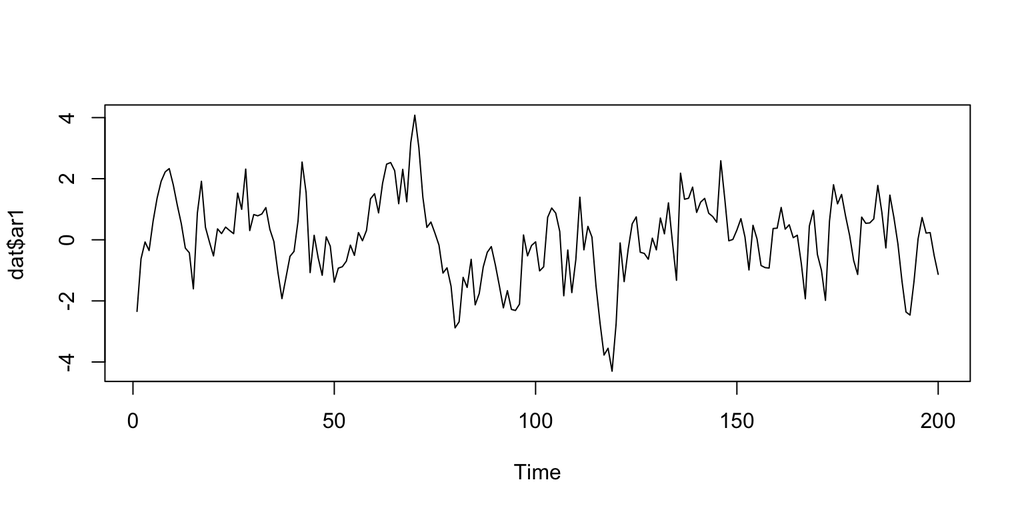

```r
plot.ts(dat$ar1)
```

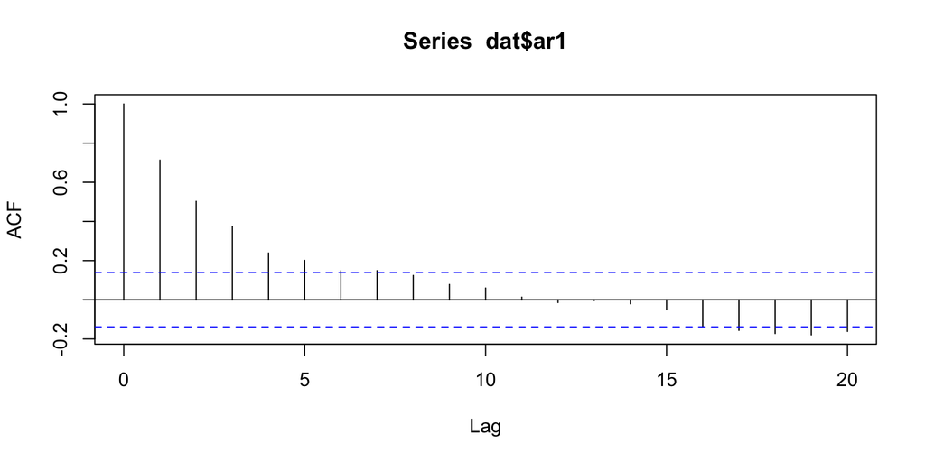

```r
acf(dat$ar1, lag.max = 20)
```

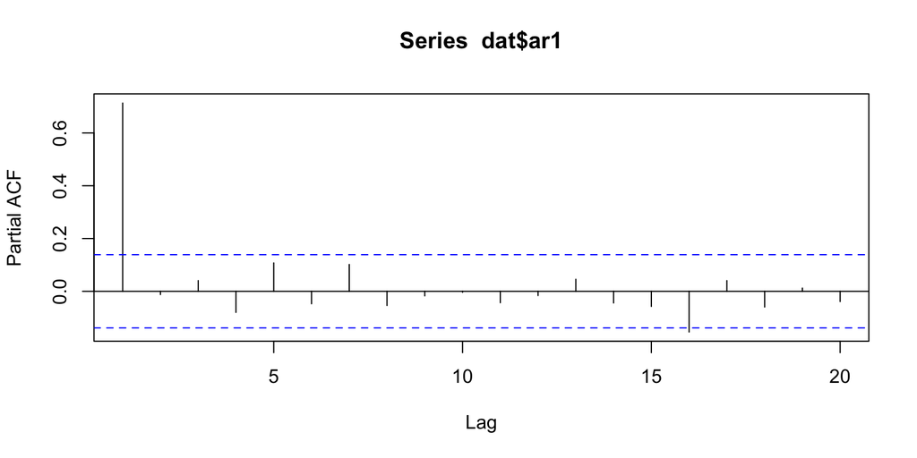

```r
pacf(dat$ar1, lag.max = 20)
```

```r
Box.test(dat$ar1, lag = 2, type = "Ljung-Box")
```

```
##
##  Box-Ljung test
##
## data:  dat$ar1
## X-squared = 154.86, df = 2, p-value < 2.2e-16
```

```r
Box.test(dat$ar1, lag = 1, type = "Ljung-Box") # in fact both path the test
```

```
##
##  Box-Ljung test
##
## data:  dat$ar1
## X-squared = 103.29, df = 1, p-value < 2.2e-16
```

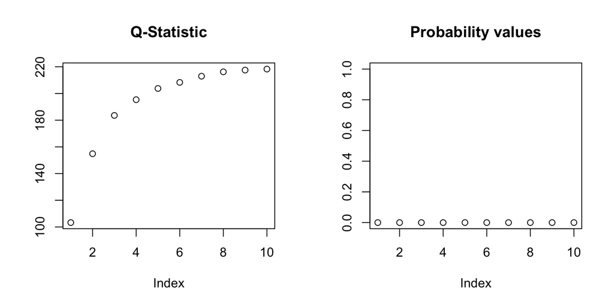

```r
# So we need to compare different lags

Q_stat <- rep(0, 10)
Q_prob <- rep(0, 10)

for (i in 1:10) {
  Q_stat[i] <- Box.test(dat$ar1, lag=i, type="Ljung-Box")$statistic
  Q_prob[i] <- Box.test(dat$ar1, lag=i, type="Ljung-Box")$p.value
}

op <- par(mfrow = c(1, 2)) # create plot area of (1 X 2)
 plot(Q_stat, ylab = "", main = 'Q-Statistic') # here we can see after 1 there is a dramatical increasing in Q-statistic
 plot(Q_prob, ylab = "", ylim = c(0,1), main = 'Probability values')
```

```r
par(op) # close plot area

## estimate

# we can use arima model to estiate it
arma100 <- arima(dat$ar1, order = c(1, 0, 0), include.mean = FALSE)

arma100 # arima.sim(model = list(ar = 0.8), n = 200)
```

```
##
## Call:
## arima(x = dat$ar1, order = c(1, 0, 0), include.mean = FALSE)
##
## Coefficients:
##          ar1
##       0.7234
## s.e.  0.0491
##
## sigma^2 estimated as 0.8744:  log likelihood = -270.74,  aic = 545.48
```

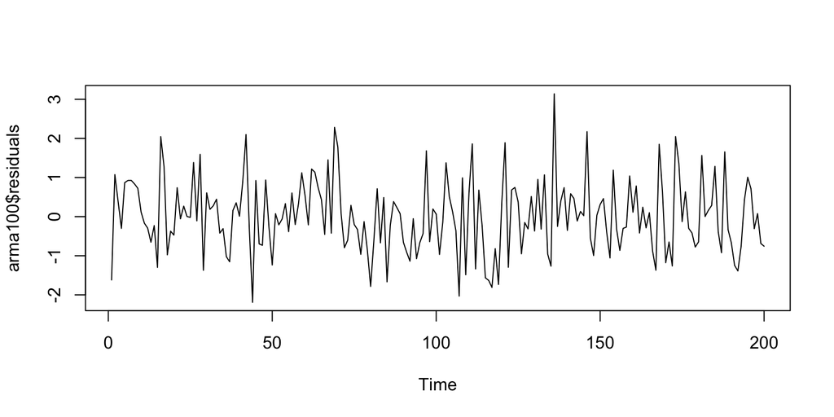

```r
# after estimate we need to check the residuals
plot(arma100$residuals)
```

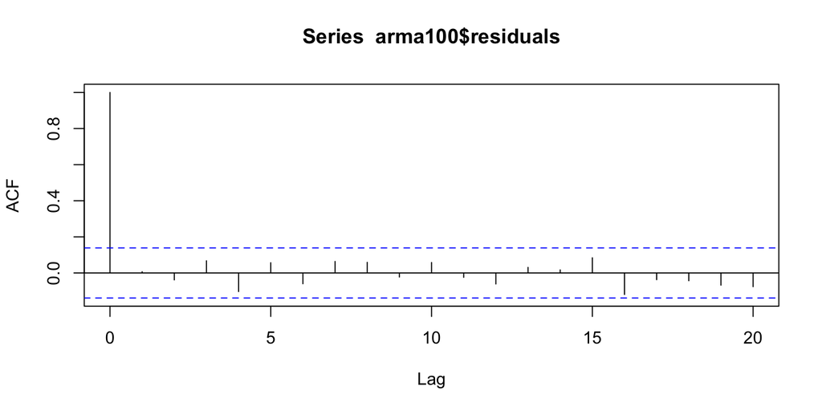

```r
acf(arma100$residuals, lag.max = 20) # check the residuals are white noise
```

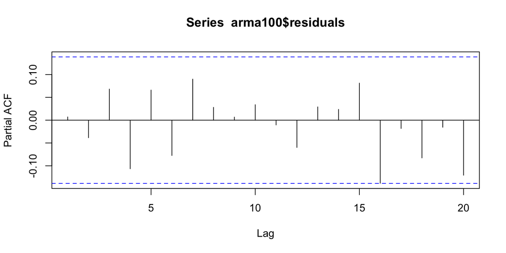

```r
pacf(arma100$residuals, lag.max = 20)
```

## 1.2 AR(p)

$$y_t = \sum_{i = 1}^p \phi_iy_{t - i} + \varepsilon_t$$

Rewrite AR(p) we have:

$$Z_{t}= \left[
\begin{array}{c}
{y_{t}}\\
\vdots\\
{y_{t-p + 1}}
\end{array}\right]$$

$$\upsilon _{t}= \left[
\begin{array}{c}
{\varepsilon_{t}}\\
{0}\\
\vdots\\
{0}
\end{array}\right]$$

$$\Gamma =\left[
\begin{array}{cccccc}
\phi _{1} & \phi _{2} & \phi _{2} & \dots & \phi _{p-1} & \phi _{p} \\
1 & 0 & 0 & \dots & 0 & 0 \\
0 & 1 & 0 & \dots & 0 & 0 \\
\vdots & \vdots & \vdots & \ddots & \vdots & \vdots \\
0 & 0 & 0 & \dots & 1 & 0
\end{array}\right]$$

$$\begin{equation}
Z_{t}=\Gamma Z_{t-1}+ \upsilon_{t}
\end{equation}$$

The matrix $\Gamma$ is termed the **companion form** matrix.

The eigenvalue of $\Gamma$ will satisfy characteristic equation, for AR(2): $x^{2}-\phi_{1}x-\phi_{2}=0$

### 1.2.1 Stationary condition:

If the absolute value of eigenvalue is less than 1, then p th AR is stable.

### 1.2.2 Order selection

- PACF For AR model the PACF will decay as order increasing only p is significantly different than 0. Thus, we can use pacf to determine

-MLE Using MLE method to determine which order is suitable.

# 2 Moving Average Models

## 2.1 MA(1)

$$y_{t}=\mu +\varepsilon_{t}+\theta \varepsilon_{t-1}$$

### 2.1.1 Moment

1. mean:

$$\begin{eqnarray}
\mathbb{E}\left[ y_{t}\right] &=&\mathbb{E}[\mu +\varepsilon_{t}+\theta \varepsilon_{t-1}] \\
&=&\mu +\mathbb{E}[\varepsilon_{t}]+\theta \mathbb{E}\left[ \varepsilon_{t-1}\right] \\
&=&\mu
\end{eqnarray}$$

2. Variance:

$$\begin{eqnarray}
\mathsf{var}[y_{t}] &=&\mathbb{E}\big[ y_{t}-\mathbb{E}[y_{t}] \big]^2 \\
&=&\mathbb{E}\big[ \left( \mu +\varepsilon_{t}+\theta \varepsilon_{t-1}\right) -\mu \big]^2 \\
&=&\mathbb{E}[\varepsilon_{t}]^{2}+2\theta \mathbb{E}[\varepsilon_{t}\varepsilon_{t-1}]+\mathbb{E}[\theta \varepsilon_{t-1}]^{2} \\
&=& \sigma^{2} + 0 + \theta \sigma^2 \\
&=&\left( 1+\theta^{2}\right) \sigma^{2}
\end{eqnarray}$$

3. Covariance:

3.1 if j = 1

$$\begin{eqnarray}
\mathsf{cov}[y_{t},y_{t-1}] &=&\mathbb{E}\Big[ \big( y_{t}-\mathbb{E}\left[ y_{t}\right] \big) \big( y_{t-1}-\mathbb{E}\left[ y_{t-1}\right] \big) \Big] \\
&=&\mathbb{E}\big[ \left( \varepsilon_{t}+\theta \varepsilon_{t-1}\right) \left( \varepsilon_{t-1}+\theta \varepsilon_{t-2}\right) \big] \\
&=&\mathbb{E}\left[ \varepsilon_{t}\varepsilon_{t-1}]+\theta \mathbb{E}[\varepsilon^{2}_{t-1}]+\mathbb{E}[\theta \varepsilon_{t}\varepsilon_{t-2}\right] +\mathbb{E}[\theta^{2} \varepsilon_{t-1}\varepsilon_{t-2}] \\
&=&0+\theta \sigma^{2}+0+0 \\
&=&\theta \sigma^{2}
\end{eqnarray}$$

3.2 if j > 1:

$$\begin{eqnarray}
\mathsf{cov}[y_{t},y_{t-j}] &=&\mathbb{E}\Big[ \big( y_{t}-\mathbb{E}\left[ y_{t}\right] \big) \big( y_{t-j}-\mathbb{E}\left[ y_{t-j}\right] \big) \Big] \\
&=&\mathbb{E}\big[ \left( \varepsilon_{t}+\theta \varepsilon_{t-1}\right) \left(\varepsilon_{t-j}+\theta \varepsilon_{t-j}\right) \big] \\
&=&0 \;\;\;\; \text{for} \;\; j > 1
\end{eqnarray}$$

: Neither the mean, variance nor covariances depend on time;

### 2.1.2 ACF:

$$\begin{eqnarray}
\rho \left(j\right) \equiv \frac{\gamma \left( j\right) }{\gamma \left( 0\right) } = \frac{\mathsf{cov} [ y_{t},y_{t-j} ] }{\mathsf{var} [ y_{t} ] }
\end{eqnarray}$$

$$\begin{eqnarray}
\rho \left( 1\right) &=&\frac{\theta }{\left( 1+\theta^{2}\right) } \\
\rho \left( j\right) \ &=&0 \;\;\;\; \text{for } \;\; j > 1
\end{eqnarray}$$

: for lag orders $j>1$, the ACF are zero.

### 2.1.3 Simulated MA

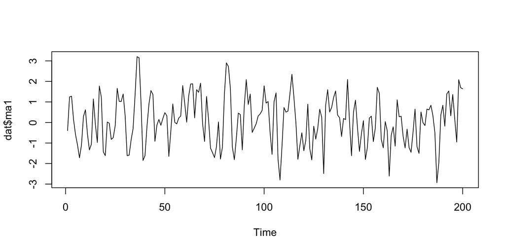

```r
plot.ts(dat$ma1)
```

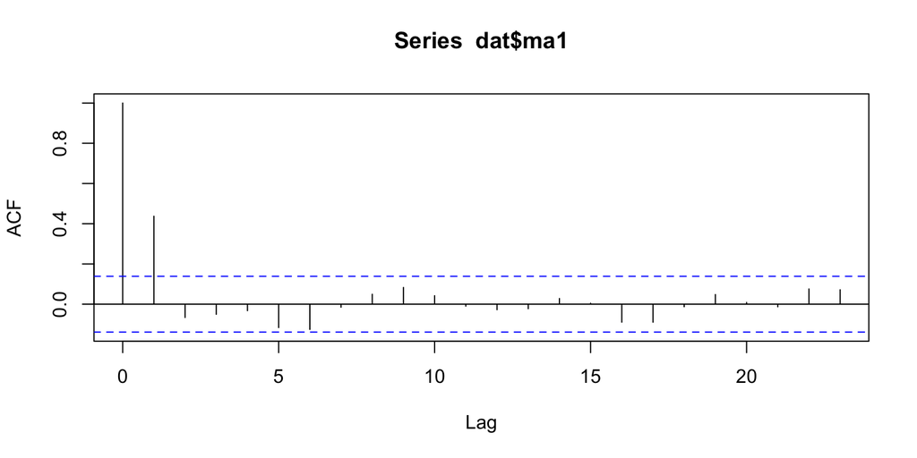

```r
acf(dat$ma1) # after 1 the ACF decay to 0
```

```r
arma001 <- arima(dat$ma1, order = c(0, 0, 1))
arma001 # arima.sim(model = list(ma = 0.7), n = 200),
```

```
##
## Call:
## arima(x = dat$ma1, order = c(0, 0, 1))
##
## Coefficients:
##          ma1  intercept
##       0.6945     0.0707
## s.e.  0.0550     0.1190
##
## sigma^2 estimated as 0.9896:  log likelihood = -283.07,  aic = 572.15
```

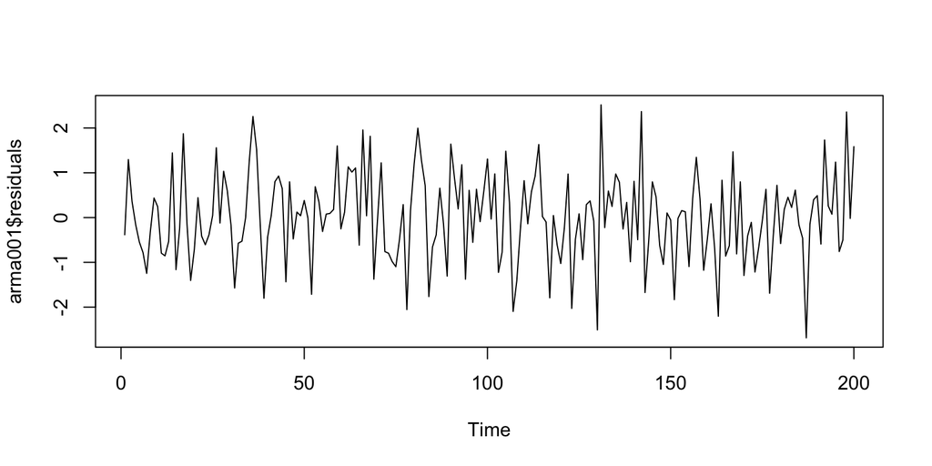

```r
# after estimate we need to check the residuals
plot(arma001$residuals)
```

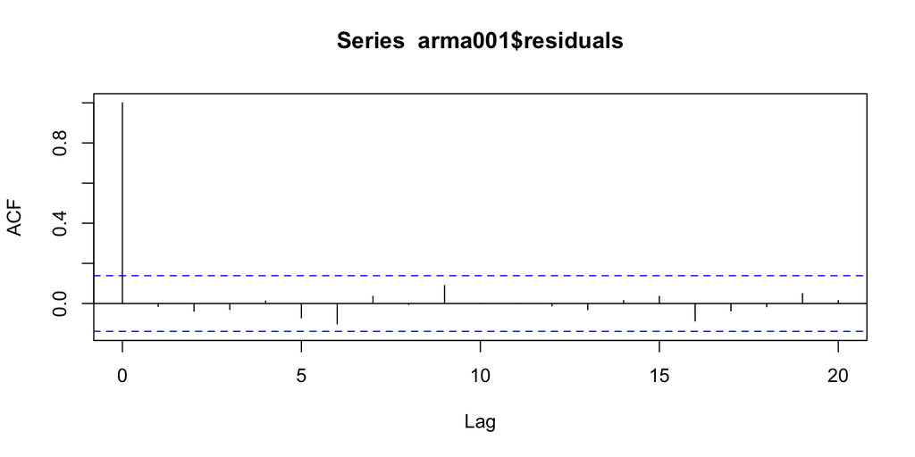

```r
acf(arma001$residuals, lag.max = 20) # check the residuals are white noise
```

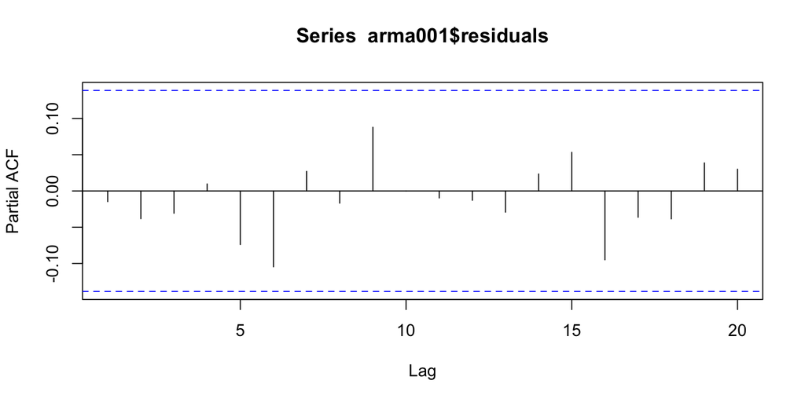

```r
pacf(arma001$residuals, lag.max = 20)
```

## 2.2 MA(q) & MA($\infty$)

MA(q):
$$\begin{equation}
y_{t}=\mu +\varepsilon_{t}+\theta_{1}\varepsilon_{t-1}+\theta_{2} \varepsilon_{t-2}+ \ldots +\theta_{q}\varepsilon_{t-q}
\end{equation}$$

MA($\infty$):

$$\begin{equation}
y_{t}=\mu +\overset{\infty }{\underset{j=0}{\sum }}\theta_{j}\varepsilon_{t-j}=\mu +\theta_{0}\varepsilon_{t}+\theta_{1}\varepsilon_{t-1}+\theta_{2}\varepsilon_{t-2}+ \ldots
\end{equation}$$

### 2.2.1 Stationary condition:

Weakly stationary condition:
$$\begin{equation}
\overset{\infty }{\underset{j=0}{\sum }}|\theta_{j}|<\infty
\end{equation}$$

covariance stationary condition:

$$\begin{equation}
\overset{\infty }{\underset{j=0}{\sum }}|\gamma_{j}|<\infty
\end{equation}$$

$$\gamma_j := cov(y_t, y_{t - j})$$

Thus, we know that we can identify the order of MA(q) process by ACF as only within order $ACF\neq 0$ otherwise equals to 0.

# 3 ARMA Models

ARMA(1, 1)

$$y_{t}=\phi y_{t-1}+\varepsilon_{t}+\theta \varepsilon_{t-1}$$

Using Lag operator:

$$\phi \left( L\right) y_{t}= \theta \left( L\right) \varepsilon_{t}$$

Multiplying by $\left( 1-\phi L\right)^{-1}$ on both sides,

$$\begin{eqnarray}
y_{t} &=&\frac{\left( 1+\theta L\right) }{\left( 1-\phi L\right) } \varepsilon_{t} \\
&=&\left( 1-\phi L\right)^{-1}\varepsilon_{t} + \left( 1-\phi L \right)^{-1} \theta_{1} \varepsilon_{t-1}
\end{eqnarray}$$

If this TS is stationary, we have

$$\begin{eqnarray}
y_{t} &=&\overset{\infty }{\underset{j=0}{\sum }}\left(\phi L\right)^{j}\varepsilon_{t}+\theta
\overset{\infty }{\underset{j=0}{\sum }}\left(\phi L\right)^{j}\varepsilon_{t-1}\\
&=&\varepsilon_{t}+\overset{\infty }{\underset{j = 1}{\sum }}\phi^{j}\varepsilon_{t-j}+\theta \overset{\infty }{\underset{j=1}{\sum }}\phi^{j-1}\varepsilon_{t-j}\\
&=&\varepsilon_{t}+\overset{\infty }{\underset{j=1}{\sum }}\left( \phi^{j}+\theta \phi^{j-1}\right) \varepsilon_{t-1}
\end{eqnarray}$$

**order selection**

Order selection mainly based on extended acf

## 3.1 Seasonal ARMA

Problem: the seasonal effect will arise to AR, MA term.

For example for ARMA model using monthly data the model will be:

$$y_t = \phi y_{t-12} + \varepsilon_t + \theta \varepsilon_{t-12}$$

dealing method: Using VAR(p) with 12 value in a vector.

## 3.2 Structural Breaks

If there is a change point we can estimate seperately, but the change point must be known a priori.

dealing method: Chow test

```r
rgdp_dat <- fred("GDPC1", "1947-01-01", "2021-04-01")[, -1] %>%
    mutate(growth = 100*(price/lag(price) - 1),
           growth_lag = lag(growth)) %>%
    drop_na()
sa_bp <- breakpoints(growth ~ growth_lag, data = rgdp_dat, breaks = 5)
summary(sa_bp)  # where the breakpoints are
```

```
##
##   Optimal (m+1)-segment partition:
##
## Call:
## breakpoints.formula(formula = growth ~ growth_lag, breaks = 5,
##     data = rgdp_dat)
##
## Breakpoints at observation number:
##
## m = 1                 250
## m = 2      75         252
## m = 3      75 138     249
## m = 4   44 88 138     249
## m = 5   44 88 138 206 250
##
## Corresponding to breakdates:
##
## m = 1
## m = 2                     0.253378378378378
## m = 3                     0.253378378378378 0.466216216216216
## m = 4   0.148648648648649 0.297297297297297 0.466216216216216
## m = 5   0.148648648648649 0.297297297297297 0.466216216216216 0.695945945945946
##
## m = 1   0.844594594594595
## m = 2   0.851351351351351
## m = 3   0.841216216216216
## m = 4   0.841216216216216
## m = 5   0.844594594594595
##
## Fit:
##
## m   0     1     2     3     4     5
## RSS 392.3 349.3 346.0 341.2 339.1 338.0
## BIC 940.5 923.1 937.5 950.3 965.6 981.8
```

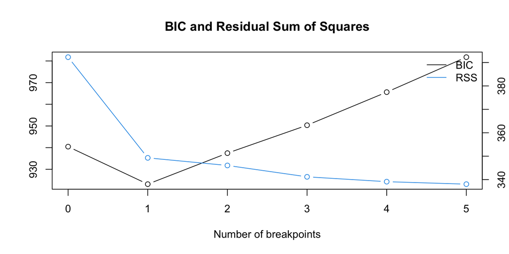

```r
plot(sa_bp, breaks = 5)
```

```r
rgdp_dat %>%
    slice(sa_bp$breakpoints) # there is a break in 2009
```

```
## # A tibble: 1 × 4
##   date        price growth growth_lag
##   <date>      <dbl>  <dbl>      <dbl>
## 1 2009-10-01 15379.   1.07      0.362
```

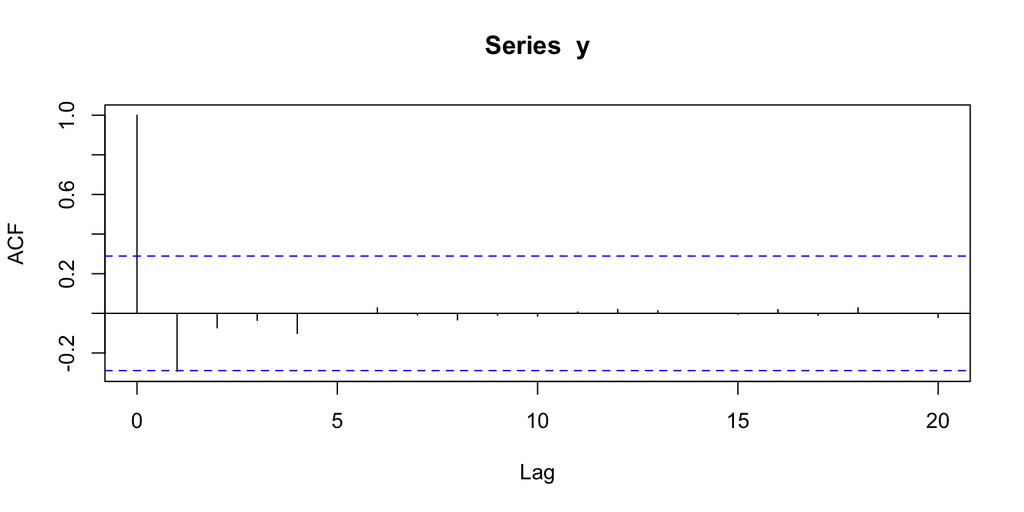

```r
# we label the subsample after 2009 as y
y <- rgdp_dat %>%
    filter(date > ymd("2009-10-01")) %>%
    pull(growth)
acf(y, lag = 20)
```

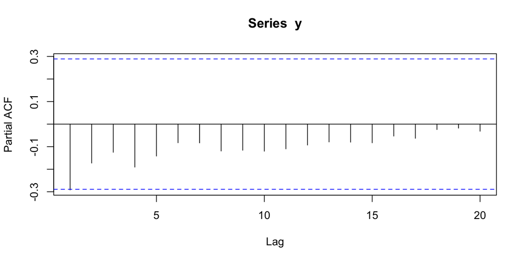

```r
pacf(y, lag = 20)
```